# Coursera Swiftkey Capstone Project - Milestone Report 1

Manav Sehgal

28th Feb, 2018

## Introduction

This report is created for the Coursera Capstone Project for the Data Specialization course. In this project, we are going to create a predictive keyboard similar to Swiftkey.

Swiftkey has partenered with Coursera and has provided the training data.

## Executive Summary

This is the first milestone report. In this week we have:

1. Loaded the training dataset: [Data](https://d396qusza40orc.cloudfront.net/dsscapstone/dataset/Coursera-SwiftKey.zip)
2. Cleaned the dataset by doing the following
- Transformed all the letters to lower case. This is done to remove capitalization of words in our prediction model. For e.g. “In” and “in” should have the same prediction.
- Removed punctuation - Our model is created only for the text words so removed punctuation so that it does not intefere in our model.
- Removed number - Same as above, our model is created only for the text words.
- Removed extra whitespaces - They are generally errors and are removed so that they are not interpreted as a word in our model
- Removed profanity words - We don’t want our model to predict profanity words so removed them from the training data set

*Note: - I have not removed stopwords (words such as “a”, “the” etc) from the training data set because we want our model to predict them*

Post data set cleanup we did some exploratory analysis on the data set and can derive the following inferences.

## Data Loading and Cleanup

For our model we will use the English datasets - news, blogs and twitter.

```r
#Set the system locale to UTF-8. This is done to correctly output special characters
Sys.setlocale("LC_CTYPE", "en_US.UTF-8")

#Set the working directory
setwd("~/Documents/Work/Study/Coursera/Data-Scientist/datasciencecoursera/Capstone Project - Swiftkey")

#Download the file
url<-"https://d396qusza40orc.cloudfront.net/dsscapstone/dataset/Coursera-SwiftKey.zip"
file_name<-"Coursera-SwiftKey.zip"
if(!file.exists(file_name)){
        download.file(url,file_name,method="curl")
}
#Create folder names
folder<-"final"
#Unzip the dataset
if(!dir.exists(folder)){
        unzip(file_name)
}

prof_file<-"/Users/manavsehgal/Documents/Work/Study/DataScientist/Profanity/en"
prof_data<-read.table(prof_file,sep="\n",colClasses = "character")
```

We can load the entire dataset but given the size, we would only need a sample of it. The distribution of a random sample should be the same as the entire dataset. For our purpose 10% of the dataset will work.

Note that we are not reading the entire dataset and then selecting a random sample. The reason for this is to use minimal memory. Reading a large dataset will require a lot of space and we want to avoid that.

I have created a function to read a sample of the data and strips the data set of extra whitespaces, foreign words and punctuations. do this for any dataset.

```r
fileToSample<-function(filename,perc=0.1){
set.seed(2)
#Load libraries
library(readr)

#Calculate the total size of the file
total_rows<-as.numeric(system(paste0("wc -l<",filename),intern = TRUE))
#Calculate the chunk size required
chunk_size<-max(floor(total_rows*perc/10),1)
#Create a vector to hold the data
data_read<-c()
#create a probability vector
prob<-rbinom(ceiling(total_rows/chunk_size),1,perc)
index<-which(prob==1)
#Run a loop to read a sample of the file.
for(i in index){
        data_read<-c(data_read,read_lines(filename,n_max = chunk_size,skip=chunk_size*(i-1)))
}

#Clean the dataset
data_read<-gsub("[0-9[:punct:]]","",data_read)#Remove numbers and punctiaons
data_read<-gsub(paste(prof_data$V1,collapse="|"),"",data_read)#remove profanity words
data_read<-gsub("[^a-zA-Z0-9[:punct:][:space:]]","",data_read)#Remove foreign words
data_read<-gsub("[[:space:]]{2,}"," ",data_read)#Remove extra whitespaces

#Return the final dataset
return(data_read)
}
```

Let’s run the function on the english datasets to load them

```r
#load libraries
library(tibble)

set.seed(2)
en_US_twitter_Sample<-fileToSample("final/en_US/en_US.twitter.txt")
en_US_blogs_Sample<-fileToSample("final/en_US/en_US.blogs.txt")
en_US_news_Sample<-fileToSample("final/en_US/en_US.news.txt")

#Combine the files and convert into a tibble
en_US_Sample<-c(en_US_twitter_Sample,en_US_blogs_Sample,en_US_news_Sample)
en_US_Sample<-tibble(en_US_Sample)
rm(en_US_twitter_Sample)
rm(en_US_blogs_Sample)
rm(en_US_news_Sample)
```

We now have a combined data set for english language that we will use for further analysis. The next step is to break down the sentences into words of 1,2 3 etc groups and count the frequencies. This is called tokenization. We will use the unnest_tokens function for this purpose as it automatically removes punctuations, converts the text into lower case etc.

```r
#Load libraries
library(tidytext)
library(dplyr)

#Create Unigram tokens
en_US_Sample_Unigram<-unnest_tokens(en_US_Sample,word,en_US_Sample,token='ngrams',n=1)
en_US_Sample_Bigram<-unnest_tokens(en_US_Sample,word,en_US_Sample,token='ngrams',n=2)
en_US_Sample_Trigram<-unnest_tokens(en_US_Sample,word,en_US_Sample,token='ngrams',n=3)
en_US_Sample_Fourgram<-unnest_tokens(en_US_Sample,word,en_US_Sample,token='ngrams',n=4)
en_US_Sample_Fivegram<-unnest_tokens(en_US_Sample,word,en_US_Sample,token='ngrams',n=5)
#Count Unigram word frequencies
en_US_Sample_Unigram_count<-en_US_Sample_Unigram%>%group_by(word)%>%count(sort=T)
en_US_Sample_Bigram_count<-en_US_Sample_Bigram%>%group_by(word)%>%count(sort=T)
en_US_Sample_Trigram_count<-en_US_Sample_Trigram%>%group_by(word)%>%count(sort=T)
en_US_Sample_Fourgram_count<-en_US_Sample_Fourgram%>%group_by(word)%>%count(sort=T)
en_US_Sample_Fivegram_count<-en_US_Sample_Fivegram%>%group_by(word)%>%count(sort=T)
```

## Exploratory Analysis

We will now do some basic analysis to understand our data better. The high level summary is below

Basic data summary

|  | total_rows | sample_rows | unique | num_50perc | num_90perc | num_single | num_multi | perc_multi |
| --- | --- | --- | --- | --- | --- | --- | --- | --- |
| Unigram | 4,269,678 | 469,645 | 226,670 | 137 | 7,746 | 132,831 | 93,839 | 98.79 |
| Bigram | 4,269,678 | 469,645 | 3,069,256 | 44,380 | 1,974,454 | 2,317,708 | 751,548 | 78.83 |
| Trigram | 4,269,678 | 469,645 | 7,528,383 | 2,054,373 | 6,433,581 | 6,678,755 | 849,628 | 39.00 |
| Fourgram | 4,269,678 | 469,645 | 9,983,061 | 4,509,052 | 8,888,259 | 9,575,422 | 407,639 | 12.54 |
| Fivegram | 4,269,678 | 469,645 | 10,711,812 | 5,237,804 | 9,617,010 | 10,574,689 | 137,123 | 3.41 |

The total unique words in our sample is **226,670** which is a good number considering the unique words in Shakespeare’s work is ~29k [(source)](https://www.opensourceshakespeare.org/stats/). However, we should note that the unique numbers may contain incorrect/misspelled words as well.

Let’s now look at the ngrams individually

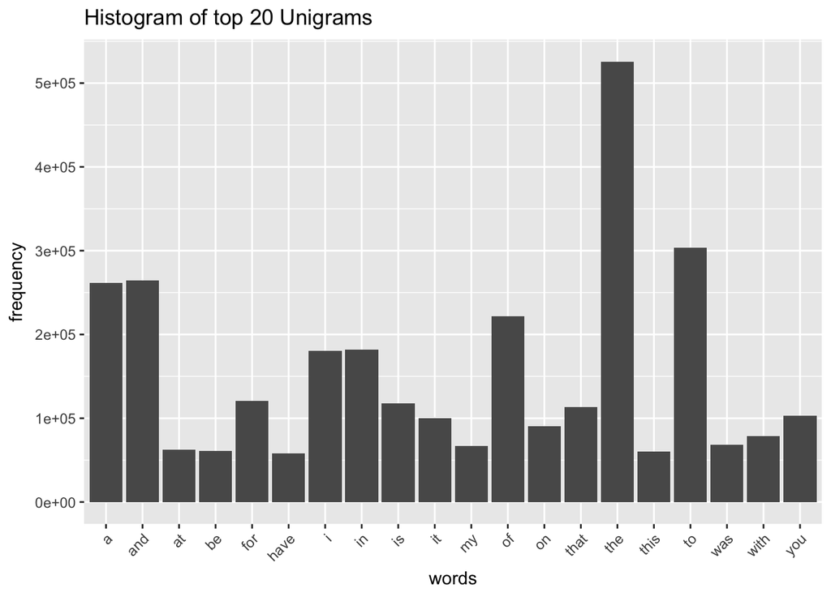

```r
library(ggplot2)
library(RColorBrewer)
library(wordcloud)

#Unigrams
ggplot(en_US_Sample_Unigram_count[1:20,],mapping=aes(x=en_US_Sample_Unigram_count$word[1:20],y=en_US_Sample_Unigram_count$n[1:20]))+geom_col()+theme(legend.position = "none",axis.text.x = element_text(angle = 45, hjust = 1))+labs(x="words",y="frequency",title="Histogram of top 20 Unigrams")
```

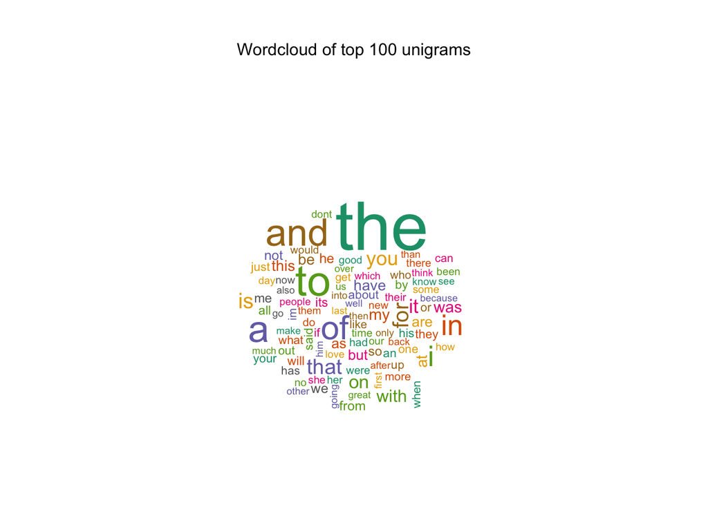

```r
pal <- brewer.pal(12,"Dark2")
layout(matrix(c(1, 2), nrow=2), heights=c(1, 4))
par(mar=rep(0, 4))
plot.new()
text(x=0.5, y=0.5, "Wordcloud of top 100 unigrams")
wordcloud(en_US_Sample_Unigram_count$word,en_US_Sample_Unigram_count$n,max.words = 100,random.color = TRUE,colors = pal)
```

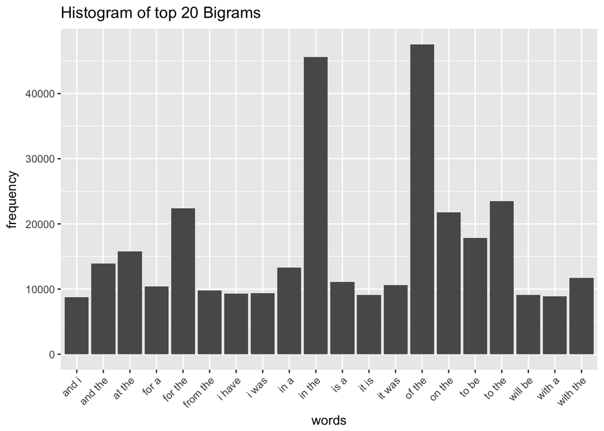

```r
#Bigrams
ggplot(en_US_Sample_Bigram_count[1:20,],mapping=aes(x=en_US_Sample_Bigram_count$word[1:20],y=en_US_Sample_Bigram_count$n[1:20]))+geom_col()+theme(legend.position = "none",axis.text.x = element_text(angle = 45, hjust = 1))+labs(x="words",y="frequency",title="Histogram of top 20 Bigrams")
```

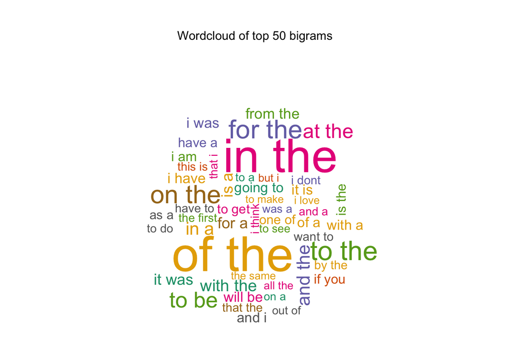

```r
pal <- brewer.pal(12,"Dark2")
layout(matrix(c(1, 2), nrow=2), heights=c(1, 4))
par(mar=rep(0, 4))
plot.new()
text(x=0.5, y=0.5, "Wordcloud of top 50 bigrams")
wordcloud(en_US_Sample_Bigram_count$word,en_US_Sample_Bigram_count$n,max.words = 50,random.color = TRUE,colors = pal)
```

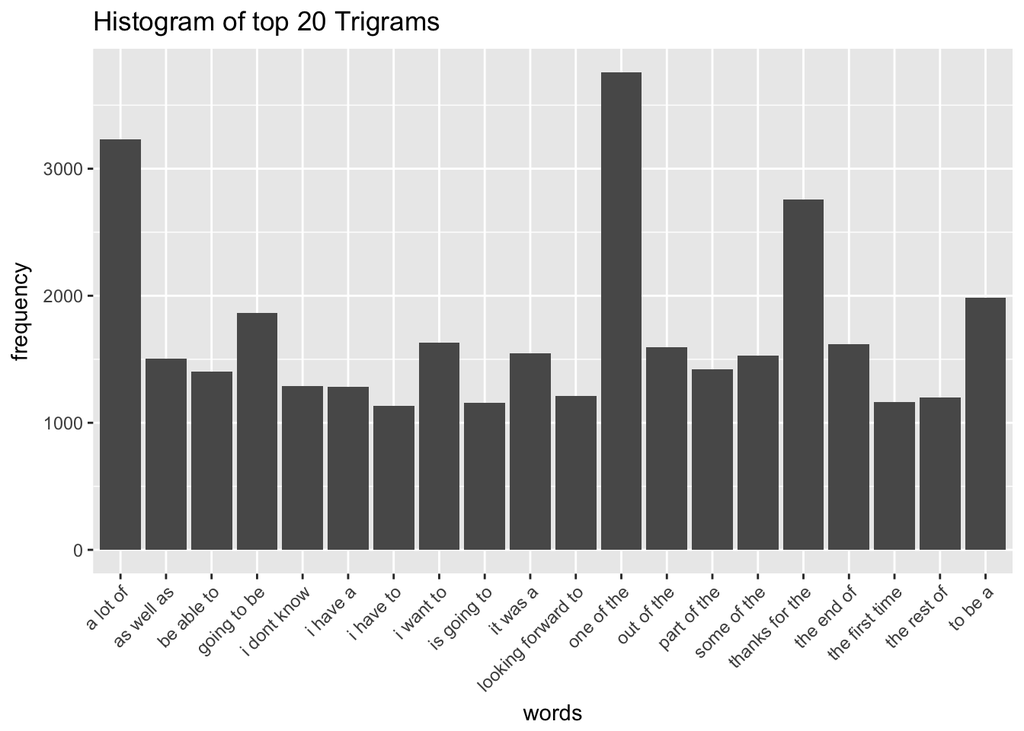

```r
#Trigrams
ggplot(en_US_Sample_Trigram_count[1:20,],mapping=aes(x=en_US_Sample_Trigram_count$word[1:20],y=en_US_Sample_Trigram_count$n[1:20]))+geom_col()+theme(legend.position = "none",axis.text.x = element_text(angle = 45, hjust = 1))+labs(x="words",y="frequency",title="Histogram of top 20 Trigrams")
```

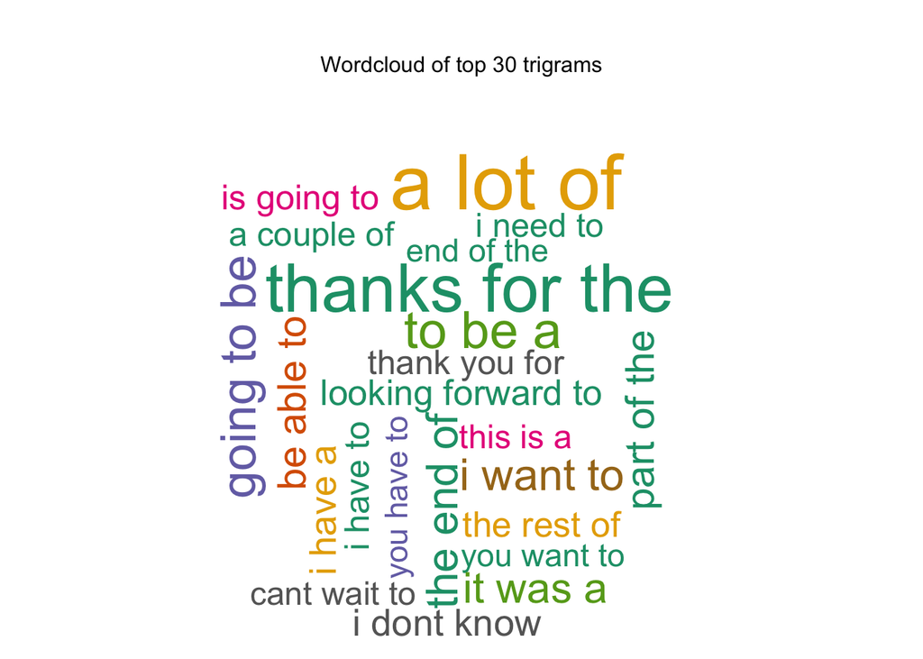

```r
pal <- brewer.pal(12,"Dark2")
layout(matrix(c(1, 2), nrow=2), heights=c(1, 4))
par(mar=rep(0, 4))
plot.new()
text(x=0.5, y=0.5, "Wordcloud of top 30 trigrams")
wordcloud(en_US_Sample_Trigram_count$word,en_US_Sample_Trigram_count$n,max.words = 30,random.color = TRUE,colors = pal)
```

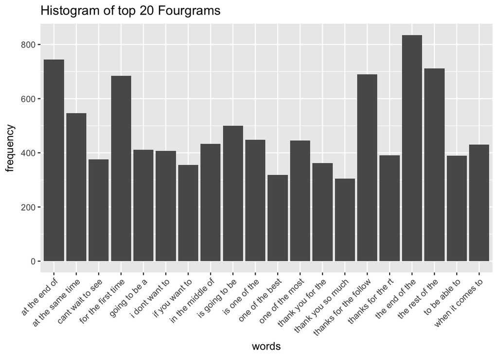

```r
#Fourgrams
ggplot(en_US_Sample_Fourgram_count[1:20,],mapping=aes(x=en_US_Sample_Fourgram_count$word[1:20],y=en_US_Sample_Fourgram_count$n[1:20]))+geom_col()+theme(legend.position = "none",axis.text.x = element_text(angle = 45, hjust = 1))+labs(x="words",y="frequency",title="Histogram of top 20 Fourgrams")
```

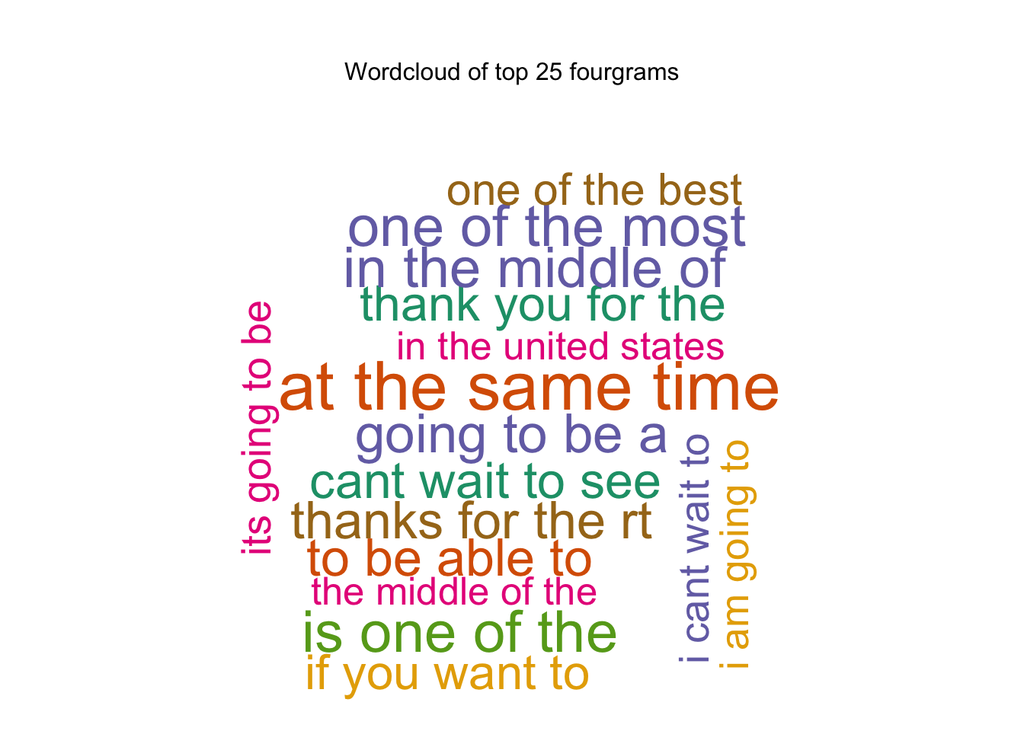

```r
pal <- brewer.pal(12,"Dark2")
layout(matrix(c(1, 2), nrow=2), heights=c(1, 4))
par(mar=rep(0, 4))
plot.new()
text(x=0.5, y=0.5, "Wordcloud of top 25 fourgrams")
wordcloud(en_US_Sample_Fourgram_count$word,en_US_Sample_Fourgram_count$n,max.words = 25,random.color = TRUE,colors = pal)
```

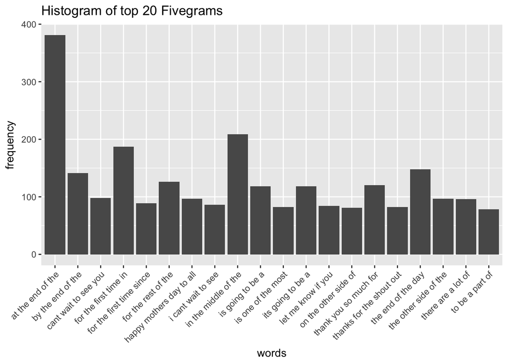

```r
#Fivegrams
ggplot(en_US_Sample_Fivegram_count[1:20,],mapping=aes(x=en_US_Sample_Fivegram_count$word[1:20],y=en_US_Sample_Fivegram_count$n[1:20]))+geom_col()+theme(legend.position = "none",axis.text.x = element_text(angle = 45, hjust = 1))+labs(x="words",y="frequency",title="Histogram of top 20 Fivegrams")
```

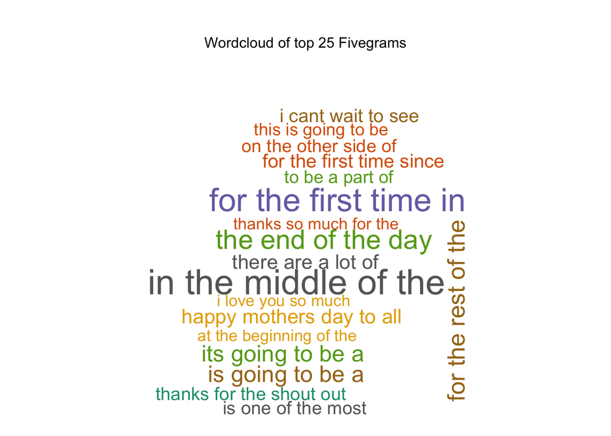

```r
pal <- brewer.pal(12,"Dark2")
layout(matrix(c(1, 2), nrow=2), heights=c(1, 4))
par(mar=rep(0, 4))
plot.new()
text(x=0.5, y=0.5, "Wordcloud of top 25 Fivegrams")
wordcloud(en_US_Sample_Fivegram_count$word,en_US_Sample_Fivegram_count$n,max.words = 25,random.color = TRUE,colors = pal)
```